# Risk Factor Analysis

## Outcome Variable

**Outcome Variable:** dead

## Predictor Variables

**Intervention Variable:** ever_underweight624

**Adjustment Set:**

unadjusted

## Stratifying Variables

The analysis was stratified on these variable(s):

- studyid
- country

## Data Summary

| studyid | country | ever_underweight624 | dead | n_cell | n |
| --- | --- | --- | --- | --- | --- |
| ki0047075b-MAL-ED | BANGLADESH | 0 | 0 | 160 | 239 |
| ki0047075b-MAL-ED | BANGLADESH | 0 | 1 | 0 | 239 |
| ki0047075b-MAL-ED | BANGLADESH | 1 | 0 | 79 | 239 |
| ki0047075b-MAL-ED | BANGLADESH | 1 | 1 | 0 | 239 |
| ki0047075b-MAL-ED | INDIA | 0 | 0 | 158 | 235 |
| ki0047075b-MAL-ED | INDIA | 0 | 1 | 0 | 235 |
| ki0047075b-MAL-ED | INDIA | 1 | 0 | 77 | 235 |
| ki0047075b-MAL-ED | INDIA | 1 | 1 | 0 | 235 |
| ki0047075b-MAL-ED | PERU | 0 | 0 | 233 | 270 |
| ki0047075b-MAL-ED | PERU | 0 | 1 | 1 | 270 |
| ki0047075b-MAL-ED | PERU | 1 | 0 | 36 | 270 |
| ki0047075b-MAL-ED | PERU | 1 | 1 | 0 | 270 |
| ki0047075b-MAL-ED | SOUTH AFRICA | 0 | 0 | 208 | 259 |
| ki0047075b-MAL-ED | SOUTH AFRICA | 0 | 1 | 0 | 259 |
| ki0047075b-MAL-ED | SOUTH AFRICA | 1 | 0 | 51 | 259 |
| ki0047075b-MAL-ED | SOUTH AFRICA | 1 | 1 | 0 | 259 |
| ki0047075b-MAL-ED | TANZANIA, UNITED REPUBLIC OF | 0 | 0 | 152 | 245 |
| ki0047075b-MAL-ED | TANZANIA, UNITED REPUBLIC OF | 0 | 1 | 0 | 245 |
| ki0047075b-MAL-ED | TANZANIA, UNITED REPUBLIC OF | 1 | 0 | 93 | 245 |
| ki0047075b-MAL-ED | TANZANIA, UNITED REPUBLIC OF | 1 | 1 | 0 | 245 |
| ki1000304-VITAMIN-A | INDIA | 0 | 0 | 2749 | 3507 |
| ki1000304-VITAMIN-A | INDIA | 0 | 1 | 8 | 3507 |
| ki1000304-VITAMIN-A | INDIA | 1 | 0 | 746 | 3507 |
| ki1000304-VITAMIN-A | INDIA | 1 | 1 | 4 | 3507 |
| ki1000304b-SAS-CompFeed | INDIA | 0 | 0 | 922 | 1386 |
| ki1000304b-SAS-CompFeed | INDIA | 0 | 1 | 8 | 1386 |
| ki1000304b-SAS-CompFeed | INDIA | 1 | 0 | 454 | 1386 |
| ki1000304b-SAS-CompFeed | INDIA | 1 | 1 | 2 | 1386 |
| ki1000304b-SAS-FoodSuppl | INDIA | 0 | 0 | 217 | 398 |
| ki1000304b-SAS-FoodSuppl | INDIA | 0 | 1 | 2 | 398 |
| ki1000304b-SAS-FoodSuppl | INDIA | 1 | 0 | 179 | 398 |
| ki1000304b-SAS-FoodSuppl | INDIA | 1 | 1 | 0 | 398 |
| ki1017093b-PROVIDE | BANGLADESH | 0 | 0 | 423 | 613 |
| ki1017093b-PROVIDE | BANGLADESH | 0 | 1 | 0 | 613 |
| ki1017093b-PROVIDE | BANGLADESH | 1 | 0 | 190 | 613 |
| ki1017093b-PROVIDE | BANGLADESH | 1 | 1 | 0 | 613 |
| ki1066203-TanzaniaChild2 | TANZANIA, UNITED REPUBLIC OF | 0 | 0 | 1699 | 2017 |
| ki1066203-TanzaniaChild2 | TANZANIA, UNITED REPUBLIC OF | 0 | 1 | 1 | 2017 |
| ki1066203-TanzaniaChild2 | TANZANIA, UNITED REPUBLIC OF | 1 | 0 | 317 | 2017 |
| ki1066203-TanzaniaChild2 | TANZANIA, UNITED REPUBLIC OF | 1 | 1 | 0 | 2017 |
| ki1101329-Keneba | GAMBIA | 0 | 0 | 1768 | 2697 |
| ki1101329-Keneba | GAMBIA | 0 | 1 | 22 | 2697 |
| ki1101329-Keneba | GAMBIA | 1 | 0 | 896 | 2697 |
| ki1101329-Keneba | GAMBIA | 1 | 1 | 11 | 2697 |
| ki1112895-Burkina Faso Zn | BURKINA FASO | 0 | 0 | 4731 | 7135 |
| ki1112895-Burkina Faso Zn | BURKINA FASO | 0 | 1 | 18 | 7135 |
| ki1112895-Burkina Faso Zn | BURKINA FASO | 1 | 0 | 2365 | 7135 |
| ki1112895-Burkina Faso Zn | BURKINA FASO | 1 | 1 | 21 | 7135 |
| ki1113344-GMS-Nepal | NEPAL | 0 | 0 | 315 | 588 |
| ki1113344-GMS-Nepal | NEPAL | 0 | 1 | 1 | 588 |
| ki1113344-GMS-Nepal | NEPAL | 1 | 0 | 272 | 588 |
| ki1113344-GMS-Nepal | NEPAL | 1 | 1 | 0 | 588 |
| ki1126311-ZVITAMBO | ZIMBABWE | 0 | 0 | 9038 | 10673 |
| ki1126311-ZVITAMBO | ZIMBABWE | 0 | 1 | 168 | 10673 |
| ki1126311-ZVITAMBO | ZIMBABWE | 1 | 0 | 1345 | 10673 |
| ki1126311-ZVITAMBO | ZIMBABWE | 1 | 1 | 122 | 10673 |
| ki1148112-iLiNS-DOSE | MALAWI | 0 | 0 | 1131 | 1693 |
| ki1148112-iLiNS-DOSE | MALAWI | 0 | 1 | 14 | 1693 |
| ki1148112-iLiNS-DOSE | MALAWI | 1 | 0 | 535 | 1693 |
| ki1148112-iLiNS-DOSE | MALAWI | 1 | 1 | 13 | 1693 |
| ki1148112-iLiNS-DYAD-M | MALAWI | 0 | 0 | 861 | 1145 |
| ki1148112-iLiNS-DYAD-M | MALAWI | 0 | 1 | 11 | 1145 |
| ki1148112-iLiNS-DYAD-M | MALAWI | 1 | 0 | 267 | 1145 |
| ki1148112-iLiNS-DYAD-M | MALAWI | 1 | 1 | 6 | 1145 |
| kiGH5241-JiVitA-3 | BANGLADESH | 0 | 0 | 13500 | 17236 |
| kiGH5241-JiVitA-3 | BANGLADESH | 0 | 1 | 128 | 17236 |
| kiGH5241-JiVitA-3 | BANGLADESH | 1 | 0 | 3587 | 17236 |
| kiGH5241-JiVitA-3 | BANGLADESH | 1 | 1 | 21 | 17236 |
| kiGH5241-JiVitA-4 | BANGLADESH | 0 | 0 | 3673 | 5419 |
| kiGH5241-JiVitA-4 | BANGLADESH | 0 | 1 | 28 | 5419 |
| kiGH5241-JiVitA-4 | BANGLADESH | 1 | 0 | 1701 | 5419 |
| kiGH5241-JiVitA-4 | BANGLADESH | 1 | 1 | 17 | 5419 |

The following strata were considered:

- studyid: ki0047075b-MAL-ED, country: BANGLADESH
- studyid: ki0047075b-MAL-ED, country: INDIA
- studyid: ki0047075b-MAL-ED, country: PERU
- studyid: ki0047075b-MAL-ED, country: SOUTH AFRICA
- studyid: ki0047075b-MAL-ED, country: TANZANIA, UNITED REPUBLIC OF
- studyid: ki1000304-VITAMIN-A, country: INDIA
- studyid: ki1000304b-SAS-CompFeed, country: INDIA
- studyid: ki1000304b-SAS-FoodSuppl, country: INDIA
- studyid: ki1017093b-PROVIDE, country: BANGLADESH
- studyid: ki1066203-TanzaniaChild2, country: TANZANIA, UNITED REPUBLIC OF
- studyid: ki1101329-Keneba, country: GAMBIA
- studyid: ki1112895-Burkina Faso Zn, country: BURKINA FASO
- studyid: ki1113344-GMS-Nepal, country: NEPAL
- studyid: ki1126311-ZVITAMBO, country: ZIMBABWE
- studyid: ki1148112-iLiNS-DOSE, country: MALAWI
- studyid: ki1148112-iLiNS-DYAD-M, country: MALAWI
- studyid: kiGH5241-JiVitA-3, country: BANGLADESH
- studyid: kiGH5241-JiVitA-4, country: BANGLADESH

### Dropped Strata

Some strata were dropped due to rare outcomes:

- studyid: ki0047075b-MAL-ED, country: BANGLADESH
- studyid: ki0047075b-MAL-ED, country: INDIA
- studyid: ki0047075b-MAL-ED, country: PERU
- studyid: ki0047075b-MAL-ED, country: SOUTH AFRICA
- studyid: ki0047075b-MAL-ED, country: TANZANIA, UNITED REPUBLIC OF
- studyid: ki1000304-VITAMIN-A, country: INDIA
- studyid: ki1000304b-SAS-CompFeed, country: INDIA
- studyid: ki1000304b-SAS-FoodSuppl, country: INDIA
- studyid: ki1017093b-PROVIDE, country: BANGLADESH
- studyid: ki1066203-TanzaniaChild2, country: TANZANIA, UNITED REPUBLIC OF
- studyid: ki1113344-GMS-Nepal, country: NEPAL

## Methods Detail

We’re interested in the causal parameters $E[Y_a]$ for all values of $a \in \mathcal{A}$. These parameters represent the mean outcome if, possibly contrary to fact, we intervened to set all units to have $A=a$. Under the randomization and positivity assumptions, these are identified by the statistical parameters $\psi_a=E_W[E_{Y|A,W}(Y|A=a,W)]$. In addition, we’re interested in the mean of $Y$, $E[Y]$ under no intervention (the observed mean). We will estimate these parameters by using SuperLearner to fit the relevant likelihood factors – $E_{Y|A,W}(Y|A=a,W)$ and $p(A=a|W)$, and then updating our likelihood fit using a joint TMLE.

For unadjusted analyses ($W=\{\}$), initial likelihoods were estimated using Lrnr_glm to estimate the simple $E(Y|A)$ and Lrnr_mean to estimate $p(A)$. For adjusted analyses, a small library containing Lrnr_glmnet, Lrnr_xgboost, and Lrnr_mean was used.

Having estimated these parameters, we will then use the delta method to estimate relative risks and attributable risks relative to a prespecified baseline level of $A$.

# Results Detail

## Results Plots

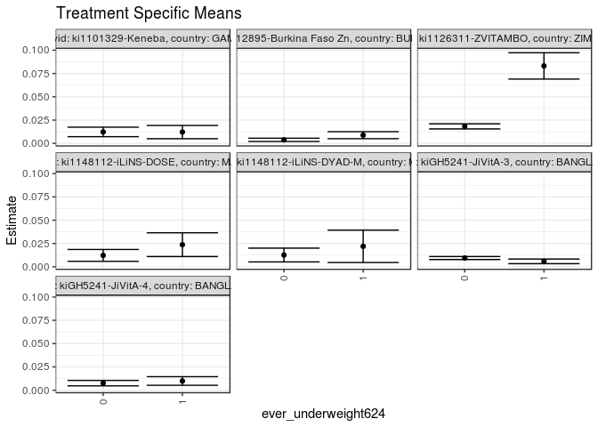

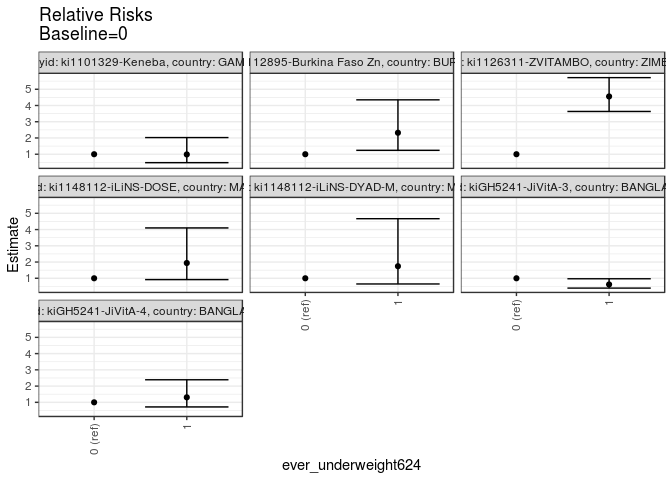

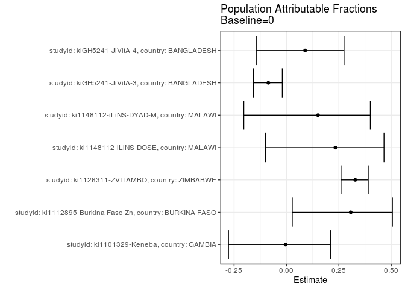

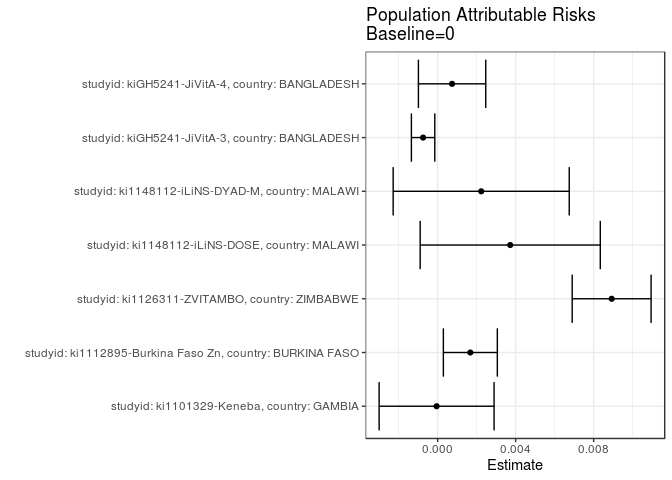

## Results Table

### Parameter: TSM

| studyid | country | intervention_level | baseline_level | estimate | ci_lower | ci_upper |
| --- | --- | --- | --- | --- | --- | --- |
| ki1101329-Keneba | GAMBIA | 0 | NA | 0.0122905 | 0.0071854 | 0.0173956 |
| ki1101329-Keneba | GAMBIA | 1 | NA | 0.0121279 | 0.0050032 | 0.0192526 |
| ki1112895-Burkina Faso Zn | BURKINA FASO | 0 | NA | 0.0037903 | 0.0020425 | 0.0055381 |
| ki1112895-Burkina Faso Zn | BURKINA FASO | 1 | NA | 0.0088013 | 0.0050534 | 0.0125493 |
| ki1126311-ZVITAMBO | ZIMBABWE | 0 | NA | 0.0182490 | 0.0155146 | 0.0209833 |
| ki1126311-ZVITAMBO | ZIMBABWE | 1 | NA | 0.0831629 | 0.0690322 | 0.0972936 |
| ki1148112-iLiNS-DOSE | MALAWI | 0 | NA | 0.0122271 | 0.0058597 | 0.0185945 |
| ki1148112-iLiNS-DOSE | MALAWI | 1 | NA | 0.0237226 | 0.0109772 | 0.0364680 |
| ki1148112-iLiNS-DYAD-M | MALAWI | 0 | NA | 0.0126147 | 0.0052039 | 0.0200254 |
| ki1148112-iLiNS-DYAD-M | MALAWI | 1 | NA | 0.0219780 | 0.0045790 | 0.0393771 |
| kiGH5241-JiVitA-3 | BANGLADESH | 0 | NA | 0.0093924 | 0.0077929 | 0.0109920 |
| kiGH5241-JiVitA-3 | BANGLADESH | 1 | NA | 0.0058204 | 0.0033434 | 0.0082974 |
| kiGH5241-JiVitA-4 | BANGLADESH | 0 | NA | 0.0075655 | 0.0046373 | 0.0104938 |
| kiGH5241-JiVitA-4 | BANGLADESH | 1 | NA | 0.0098952 | 0.0052749 | 0.0145156 |

### Parameter: E(Y)

| studyid | country | intervention_level | baseline_level | estimate | ci_lower | ci_upper |
| --- | --- | --- | --- | --- | --- | --- |
| ki1101329-Keneba | GAMBIA | NA | NA | 0.0122358 | 0.0080860 | 0.0163857 |
| ki1112895-Burkina Faso Zn | BURKINA FASO | NA | NA | 0.0054660 | 0.0037551 | 0.0071769 |
| ki1126311-ZVITAMBO | ZIMBABWE | NA | NA | 0.0271714 | 0.0240868 | 0.0302560 |
| ki1148112-iLiNS-DOSE | MALAWI | NA | NA | 0.0159480 | 0.0099789 | 0.0219171 |
| ki1148112-iLiNS-DYAD-M | MALAWI | NA | NA | 0.0148472 | 0.0078389 | 0.0218554 |
| kiGH5241-JiVitA-3 | BANGLADESH | NA | NA | 0.0086447 | 0.0072479 | 0.0100415 |
| kiGH5241-JiVitA-4 | BANGLADESH | NA | NA | 0.0083041 | 0.0058088 | 0.0107994 |

### Parameter: RR

| studyid | country | intervention_level | baseline_level | estimate | ci_lower | ci_upper |
| --- | --- | --- | --- | --- | --- | --- |
| ki1101329-Keneba | GAMBIA | 0 | 0 | 1.0000000 | 1.0000000 | 1.0000000 |
| ki1101329-Keneba | GAMBIA | 1 | 0 | 0.9867696 | 0.4805640 | 2.0261903 |
| ki1112895-Burkina Faso Zn | BURKINA FASO | 0 | 0 | 1.0000000 | 1.0000000 | 1.0000000 |
| ki1112895-Burkina Faso Zn | BURKINA FASO | 1 | 0 | 2.3220872 | 1.2396019 | 4.3498551 |
| ki1126311-ZVITAMBO | ZIMBABWE | 0 | 0 | 1.0000000 | 1.0000000 | 1.0000000 |
| ki1126311-ZVITAMBO | ZIMBABWE | 1 | 0 | 4.5571297 | 3.6333282 | 5.7158150 |
| ki1148112-iLiNS-DOSE | MALAWI | 0 | 0 | 1.0000000 | 1.0000000 | 1.0000000 |
| ki1148112-iLiNS-DOSE | MALAWI | 1 | 0 | 1.9401721 | 0.9180933 | 4.1000926 |
| ki1148112-iLiNS-DYAD-M | MALAWI | 0 | 0 | 1.0000000 | 1.0000000 | 1.0000000 |
| ki1148112-iLiNS-DYAD-M | MALAWI | 1 | 0 | 1.7422577 | 0.6500948 | 4.6692604 |
| kiGH5241-JiVitA-3 | BANGLADESH | 0 | 0 | 1.0000000 | 1.0000000 | 1.0000000 |
| kiGH5241-JiVitA-3 | BANGLADESH | 1 | 0 | 0.6196908 | 0.3957010 | 0.9704717 |
| kiGH5241-JiVitA-4 | BANGLADESH | 0 | 0 | 1.0000000 | 1.0000000 | 1.0000000 |
| kiGH5241-JiVitA-4 | BANGLADESH | 1 | 0 | 1.3079370 | 0.7159588 | 2.3893821 |

### Parameter: PAR

| studyid | country | intervention_level | baseline_level | estimate | ci_lower | ci_upper |
| --- | --- | --- | --- | --- | --- | --- |
| ki1101329-Keneba | GAMBIA | 0 | NA | -0.0000547 | -0.0030023 | 0.0028929 |
| ki1112895-Burkina Faso Zn | BURKINA FASO | 0 | NA | 0.0016757 | 0.0002917 | 0.0030598 |
| ki1126311-ZVITAMBO | ZIMBABWE | 0 | NA | 0.0089224 | 0.0068992 | 0.0109456 |
| ki1148112-iLiNS-DOSE | MALAWI | 0 | NA | 0.0037209 | -0.0008979 | 0.0083398 |
| ki1148112-iLiNS-DYAD-M | MALAWI | 0 | NA | 0.0022325 | -0.0022825 | 0.0067474 |
| kiGH5241-JiVitA-3 | BANGLADESH | 0 | NA | -0.0007477 | -0.0013477 | -0.0001478 |
| kiGH5241-JiVitA-4 | BANGLADESH | 0 | NA | 0.0007386 | -0.0009880 | 0.0024652 |

### Parameter: PAF

| studyid | country | intervention_level | baseline_level | estimate | ci_lower | ci_upper |
| --- | --- | --- | --- | --- | --- | --- |
| ki1101329-Keneba | GAMBIA | 0 | NA | -0.0044693 | -0.2767079 | 0.2097186 |
| ki1112895-Burkina Faso Zn | BURKINA FASO | 0 | NA | 0.3065747 | 0.0275954 | 0.5055158 |
| ki1126311-ZVITAMBO | ZIMBABWE | 0 | NA | 0.3283750 | 0.2602782 | 0.3902031 |
| ki1148112-iLiNS-DOSE | MALAWI | 0 | NA | 0.2333172 | -0.0995890 | 0.4654343 |
| ki1148112-iLiNS-DYAD-M | MALAWI | 0 | NA | 0.1503643 | -0.2036237 | 0.4002437 |
| kiGH5241-JiVitA-3 | BANGLADESH | 0 | NA | -0.0864958 | -0.1574589 | -0.0198834 |
| kiGH5241-JiVitA-4 | BANGLADESH | 0 | NA | 0.0889429 | -0.1443046 | 0.2746468 |